# 공연_현황_분석_정한수

## Pandas Team Project 1조 정한수

- 데이터 처리 및 분석

```python
import pandas as pd
```

#### 통합한 자료 불러오기

```python
daegu_show = pd.read_csv('./deagu_show.csv')
seoul_show = pd.read_csv('./seoul_show.csv')
seoul_yanolza = pd.read_csv('./seoul_yanolza.csv')
daegu_yanolza = pd.read_csv('./deagu_yanolza.csv')
```

```python
datas = [daegu_show, seoul_show, daegu_yanolza,seoul_yanolza]
for data in datas :
    print(data.info(), '\n')
```

```
<class 'pandas.core.frame.DataFrame'>
RangeIndex: 1090 entries, 0 to 1089
Data columns (total 25 columns):
 #   Column    Non-Null Count  Dtype
---  ------    --------------  -----
 0   행사명       1090 non-null   object
 1   장소        1090 non-null   object
 2   행사내용      1090 non-null   object
 3   행사시작일자    1090 non-null   object
 4   행사종료일자    1090 non-null   object
 5   행사시작시각    1090 non-null   object
 6   행사종료시각    1090 non-null   object
 7   요금정보      1090 non-null   object
 8   주관기관      1090 non-null   object
 9   주최기관      1090 non-null   object
 10  전화번호      956 non-null    object
 11  후원기관      118 non-null    object
 12  객석수       1063 non-null   float64
 13  관람요금      999 non-null    object
 14  입장연령      993 non-null    object
 15  할인정보      955 non-null    object
 16  유의사항      0 non-null      float64
 17  홈페이지주소    1022 non-null   object
 18  예매정보      806 non-null    object
 19  주차장보유여부   1054 non-null   object
 20  소재지도로명주소  1090 non-null   object
 21  소재지지번주소   993 non-null    object
 22  위도        1090 non-null   float64
 23  경도        1090 non-null   float64
 24  데이터기준일자   1090 non-null   object
dtypes: float64(4), object(21)
memory usage: 213.0+ KB
None

<class 'pandas.core.frame.DataFrame'>
RangeIndex: 156 entries, 0 to 155
Data columns (total 26 columns):
 #   Column    Non-Null Count  Dtype
---  ------    --------------  -----
 0   행사명       156 non-null    object
```

[output cut: 41 more lines]

```
None

<class 'pandas.core.frame.DataFrame'>
RangeIndex: 5603 entries, 0 to 5602
Data columns (total 5 columns):
 #   Column                          Non-Null Count  Dtype
---  ------                          --------------  -----
 0   AREA_NM                         5603 non-null   object
 1   PBLPRFR_ND_DSPY_GOODS_CD        5603 non-null   int64
 2   PBLPRFR_ND_DSPY_GOODS_NM        5603 non-null   object
 3   PBLPRFR_ND_DSPY_GOODS_ADDR      5510 non-null   object
 4   PBLPRFR_ND_DSPY_GOODS_RNEWL_DE  5603 non-null   int64
dtypes: int64(2), object(3)
memory usage: 219.0+ KB
None
```

### 야놀자 자료 처리

```python
daegu_yanolza
```

|  | AREA_NM | PBLPRFR_ND_DSPY_GOODS_CD | PBLPRFR_ND_DSPY_GOODS_NM | PBLPRFR_ND_DSPY_GOODS_ADDR | PBLPRFR_ND_DSPY_GOODS_RNEWL_DE |
| --- | --- | --- | --- | --- | --- |
| 0 | 대구 달서구 | 48254 | [대구 달서] 이월드 83타워 무슈샤 전시회 | 대구 달서구 두류공원로 200 | 20200831 |
| 1 | 대구 달서구 | 49168 | [대구 달서] 이월드 83타워 무슈샤 전시회 12월 | 대구 달서구 두류공원로 200 | 20200831 |
| 2 | 대구 달서구 | 50472 | [대구 달서] 이월드 83타워 무슈샤 전시회 1월 | 대구 달서구 두류공원로 200 | 20200831 |
| 3 | 대구 달서구 | 51196 | [대구 달서] 이월드 83타워 무슈샤 전시회 2월 | 대구 달서구 두류공원로 200 | 20200831 |
| 4 | 대구 달서구 | 51360 | [대구 달서] 이월드 83타워 전망대&아이스링크&전시PKG 2월 | 대구 달서구 두류공원로 200 | 20200831 |
| 5 | 대구 달성군 | 46490 | [파주] 이연호 마술&버블쇼 | 대구 달성군 가창면 가창로 891 | 20200930 |
| 6 | 대구 달성군 | 52585 | [경기 파주] 이연호 마술&버블쇼 | 대구 달성군 가창면 가창로 891 | 20200930 |
| 7 | 대구 달성군 | 46490 | [파주] 이연호 마술&버블쇼 | 대구 달성군 가창면 가창로 891 | 20201031 |
| 8 | 대구 달성군 | 52585 | [경기 파주] 이연호 마술&버블쇼 | 대구 달성군 가창면 가창로 891 | 20201031 |
| 9 | 대구 달성군 | 46490 | [파주] 이연호 마술&버블쇼 | 대구 달성군 가창면 가창로 891 | 20201130 |
| 10 | 대구 달성군 | 52585 | [경기 파주] 이연호 마술&버블쇼 | 대구 달성군 가창면 가창로 891 | 20201130 |
| 11 | 대구 달성군 | 46490 | [파주] 이연호 마술&버블쇼 | 대구 달성군 가창면 가창로 891 | 20201231 |
| 12 | 대구 달성군 | 52585 | [경기 파주] 이연호 마술&버블쇼 | 대구 달성군 가창면 가창로 891 | 20201231 |
| 13 | 대구 달성군 | 46490 | [파주] 이연호 마술&버블쇼 | 대구 달성군 가창면 가창로 891 | 20210131 |
| 14 | 대구 달성군 | 52585 | [경기 파주] 이연호 마술&버블쇼 | 대구 달성군 가창면 가창로 891 | 20210131 |
| 15 | 대구 달성군 | 46490 | [파주] 이연호 마술&버블쇼 | 대구 달성군 가창면 가창로 891 | 20210228 |
| 16 | 대구 달성군 | 52585 | [경기 파주] 이연호 마술&버블쇼 | 대구 달성군 가창면 가창로 891 | 20210228 |
| 17 | 대구 달성군 | 46490 | [파주] 이연호 마술&버블쇼 | 대구 달성군 가창면 가창로 891 | 20210330 |
| 18 | 대구 달성군 | 52585 | [경기 파주] 이연호 마술&버블쇼 | 대구 달성군 가창면 가창로 891 | 20210330 |
| 19 | 대구 달성군 | 46490 | [파주] 이연호 마술&버블쇼 | 대구 달성군 가창면 가창로 891 | 20210430 |
| 20 | 대구 달성군 | 52585 | [경기 파주] 이연호 마술&버블쇼 | 대구 달성군 가창면 가창로 891 | 20210430 |
| 21 | 대구 달성군 | 46490 | [파주] 이연호 마술&버블쇼 | 대구 달성군 가창면 가창로 891 | 20210531 |
| 22 | 대구 달성군 | 52585 | [경기 파주] 이연호 마술&버블쇼 | 대구 달성군 가창면 가창로 891 | 20210531 |
| 23 | 대구 달성군 | 46490 | [파주] 이연호 마술&버블쇼 | 대구 달성군 가창면 가창로 891 | 20210630 |
| 24 | 대구 달성군 | 52585 | [경기 파주] 이연호 마술&버블쇼 | 대구 달성군 가창면 가창로 891 | 20210630 |
| 25 | 대구 달성군 | 46490 | [파주] 이연호 마술&버블쇼 | 대구 달성군 가창면 가창로 891 | 20210630 |
| 26 | 대구 달성군 | 52585 | [경기 파주] 이연호 마술&버블쇼 | 대구 달성군 가창면 가창로 891 | 20210630 |
| 27 | 대구 달성군 | 46490 | [파주] 이연호 마술&버블쇼 | 대구 달성군 가창면 가창로 891 | 20210731 |
| 28 | 대구 달성군 | 52585 | [경기 파주] 이연호 마술&버블쇼 | 대구 달성군 가창면 가창로 891 | 20210731 |
| 29 | 대구 달성군 | 46490 | [파주] 이연호 마술&버블쇼 | 대구 달성군 가창면 가창로 891 | 20210930 |
| 30 | 대구 달성군 | 52585 | [경기 파주] 이연호 마술&버블쇼 | 대구 달성군 가창면 가창로 891 | 20210930 |
| 31 | 대구 달성군 | 46490 | [파주] 이연호 마술&버블쇼 | 대구 달성군 가창면 가창로 891 | 20211031 |
| 32 | 대구 달성군 | 52585 | [경기 파주] 이연호 마술&버블쇼 | 대구 달성군 가창면 가창로 891 | 20211031 |
| 33 | 대구 달성군 | 46490 | [파주] 이연호 마술&버블쇼 | 대구 달성군 가창면 가창로 891 | 20211130 |
| 34 | 대구 달성군 | 52585 | [경기 파주] 이연호 마술&버블쇼 | 대구 달성군 가창면 가창로 891 | 20211130 |
| 35 | 대구 달성군 | 46490 | [파주] 이연호 마술&버블쇼 | 대구 달성군 가창면 가창로 891 | 20211231 |
| 36 | 대구 달성군 | 52585 | [경기 파주] 이연호 마술&버블쇼 | 대구 달성군 가창면 가창로 891 | 20211231 |
| 37 | 대구광역시 수성구 | 79806 | [대구] 아이니테마파크 겨울방학 한정특가 | 대구광역시 수성구 유니버시아드로 140 | 20211231 |
| 38 | 대구 달성군 | 46490 | [파주] 이연호 마술&버블쇼 | 대구 달성군 가창면 가창로 891 | 20220131 |
| 39 | 대구 달성군 | 52585 | [경기 파주] 이연호 마술&버블쇼 | 대구 달성군 가창면 가창로 891 | 20220131 |
| 40 | 대구광역시 수성구 | 79806 | [대구] 아이니테마파크 실내동물원 | 대구광역시 수성구 유니버시아드로 140 | 20220131 |
| 41 | 대구 달성군 | 46490 | [파주] 이연호 마술&버블쇼 | 대구 달성군 가창면 가창로 891 | 20220228 |
| 42 | 대구 달성군 | 52585 | [경기 파주] 이연호 마술&버블쇼 | 대구 달성군 가창면 가창로 891 | 20220228 |
| 43 | 대구광역시 수성구 | 79806 | [대구] 아이니테마파크 실내동물원 | 대구광역시 수성구 유니버시아드로 140 | 20220228 |
| 44 | 대구 달성군 | 46490 | [파주] 이연호 마술&버블쇼 | 대구 달성군 가창면 가창로 891 | 20220331 |
| 45 | 대구 달성군 | 52585 | [경기 파주] 이연호 마술&버블쇼 | 대구 달성군 가창면 가창로 891 | 20220331 |
| 46 | 대구광역시 수성구 | 79806 | [대구] 아이니테마파크 실내동물원 | 대구광역시 수성구 유니버시아드로 140 | 20220331 |
| 47 | 대구 달성군 | 46490 | [파주] 이연호 마술&버블쇼 | 대구 달성군 가창면 가창로 891 | 20220430 |
| 48 | 대구 달성군 | 52585 | [경기 파주] 이연호 마술&버블쇼 | 대구 달성군 가창면 가창로 891 | 20220430 |
| 49 | 대구광역시 수성구 | 79806 | [대구] 아이니테마파크 실내동물원 | 대구광역시 수성구 유니버시아드로 140 | 20220430 |
| 50 | 대구 달성군 | 46490 | [파주] 이연호 마술&버블쇼 | 대구 달성군 가창면 가창로 891 | 20220531 |
| 51 | 대구 달성군 | 52585 | [경기 파주] 이연호 마술&버블쇼 | 대구 달성군 가창면 가창로 891 | 20220531 |
| 52 | 대구광역시 수성구 | 79806 | [대구] 아이니테마파크 실내동물원 | 대구광역시 수성구 유니버시아드로 140 | 20220531 |
| 53 | 대구 달성군 | 46490 | [파주] 이연호 마술&버블쇼 | 대구 달성군 가창면 가창로 891 | 20220630 |
| 54 | 대구 달성군 | 52585 | [경기 파주] 이연호 마술&버블쇼 | 대구 달성군 가창면 가창로 891 | 20220630 |
| 55 | 대구광역시 달서구 | 85639 | [대구 달서] 짱구 페스티벌 짱구야 캠핑 가자 대구순회전시 | 대구광역시 달서구 두류공원로 200 | 20220630 |
| 56 | 대구광역시 수성구 | 79806 | [대구] 아이니테마파크 실내동물원 | 대구광역시 수성구 유니버시아드로 140 | 20220630 |

#### column 선택, rename

```python
daegu_yanolza.drop(['PBLPRFR_ND_DSPY_GOODS_CD', 'PBLPRFR_ND_DSPY_GOODS_ADDR'], axis = 1, inplace= True)
seoul_yanolza.drop(['PBLPRFR_ND_DSPY_GOODS_CD', 'PBLPRFR_ND_DSPY_GOODS_ADDR'], axis = 1, inplace= True)

daegu_yanolza.rename(columns = { 'AREA_NM': '지역', 'PBLPRFR_ND_DSPY_GOODS_NM' : '행사명', 'PBLPRFR_ND_DSPY_GOODS_RNEWL_DE': '시행월'}, inplace=True)
seoul_yanolza.rename(columns = { 'AREA_NM': '지역', 'PBLPRFR_ND_DSPY_GOODS_NM' : '행사명', 'PBLPRFR_ND_DSPY_GOODS_RNEWL_DE': '시행월'}, inplace=True)
```

#### 행사 시행 월 별로 구분하기

```python
daegu_yanolza['시행월'] = [str(x)[:-2] for x in daegu_yanolza['시행월']]
seoul_yanolza['시행월'] = [str(x)[:-2] for x in seoul_yanolza['시행월']]
```

```python
seoul_yanolza
```

|  | 지역 | 행사명 | 시행월 |
| --- | --- | --- | --- |
| 0 | 서울 강남구 | [서울 강남] 전시 위대한낙서展 : OBEY THE MOVEMENT | 202008 |
| 1 | 서울 강남구 | [서울 강남] K현대미술관 이상한나라의 괴짜들 | 202008 |
| 2 | 서울 강남구 | [서울 강남] 전시 위대한낙서展 : OBEY THE MOVEMENT : ★핫딜 특가 | 202008 |
| 3 | 서울 강남구 | [서울 강남] 마녀의 초대장★전시 | 202008 |
| 4 | 서울 강남구 | [서울 강남] 산타와 빈양말 : 어린이 뮤지컬 | 202008 |
| ... | ... | ... | ... |
| 5598 | 서울특별시 중구 | [★단독특가] 살바도르 달리전 얼리버드 | 202206 |
| 5599 | 서울특별시 중구 | [서울 중구] 살바도르 달리전 | 202206 |
| 5600 | 서울특별시 중구 | [서울 중구] 살바도르 달리전 | 202206 |
| 5601 | 서울특별시 중구 | [서울 중구] ★특가★ 살바도르 달리전 | 202206 |
| 5602 | 서울특별시 중구 | [서울 중구] [시작된 미래] Meta-Horizons : The Future Now | 202206 |

5603 rows × 3 columns

### 공공데이터 행사 기록

#### column 선택, rename

```python
target_col = ['행사명', '장소','소재지도로명주소', '행사시작일자']
```

```python
seoul_show = seoul_show[target_col].sort_values('행사시작일자').reset_index(drop = True)
daegu_show = daegu_show[target_col].sort_values('행사시작일자').reset_index(drop = True)
```

```python
daegu_show.rename(columns = {'행사시작일자' : '시행월'},inplace = True)
seoul_show.rename(columns = {'행사시작일자' : '시행월'},inplace = True)
```

#### 2019년 부터의 자료만 사용하기

```python
date_range = ['2019-01', '2022-06']
```

```python
seoul_show = seoul_show[(seoul_show['시행월'] >= date_range[0]) *
                        (seoul_show['시행월'] <= date_range[1])]
daegu_show = daegu_show[(daegu_show['시행월'] >= date_range[0]) *
                        (daegu_show['시행월'] <= date_range[1])]
```

#### 행사 시행 월 별로 구분하기

```python
daegu_show['시행월'] = [x[:4] + x[5:7] for x in daegu_show['시행월']]
seoul_show['시행월'] = [x[:4] + x[5:7] for x in seoul_show['시행월']]
```

```python
daegu_show
```

|  | 행사명 | 장소 | 소재지도로명주소 | 시행월 |
| --- | --- | --- | --- | --- |
| 484 | 2019 웨스턴심포니 오케스트라와 함께하는 신년음악회 with 장사익 | 봉산문화회관 가온홀 | 대구광역시 중구 봉산문화길 77 | 201901 |
| 485 | 가족뮤지컬 렛잇고 | 봉산문화회관 가온홀 | 대구광역시 중구 봉산문화길 77 | 201901 |
| 486 | 가족뮤지컬 렛잇고 | 봉산문화회관 가온홀 | 대구광역시 중구 봉산문화길 77 | 201901 |
| 487 | 가족뮤지컬 렛잇고 | 봉산문화회관 가온홀 | 대구광역시 중구 봉산문화길 77 | 201901 |
| 488 | 가족뮤지컬 렛잇고 | 봉산문화회관 가온홀 | 대구광역시 중구 봉산문화길 77 | 201901 |
| ... | ... | ... | ... | ... |
| 1079 | 음악무용극 불켜는 아이 | 봉산문화회관 가온홀 | 대구광역시 중구 봉산문화길 77 | 202205 |
| 1080 | 향기의 미술관 | 대구음악창작소 창공홀 | 대구광역시 남구 앞산순환로 478 | 202205 |
| 1081 | 마임연극<내 마음에 꽃이 피었습니다> | 어울아트센터 오봉홀 | 대구광역시 북구 구암로 47(관음동) | 202205 |
| 1082 | 소소스테이지I - 퍼플엘리 of 비아트리오 | 봉산문화회관 스페이스라온 | 대구광역시 중구 봉산문화길 77 | 202205 |
| 1083 | 마토콘서트 <퓨전 마당극 춘심홍로줄> | 이현공원 야외공연장 | 대구광역시 서구 당산로 403 | 202205 |

600 rows × 4 columns

```python
seoul_show
```

|  | 행사명 | 장소 | 소재지도로명주소 | 시행월 |
| --- | --- | --- | --- | --- |
| 4 | 안산해맞이 | 안산봉수대 | 서울특별시 서대문구 연희로 248 | 201901 |
| 5 | 2019 신년음악회 | 양천문화회관 대극장 | 서울특별시 양천구 목동서로 367 | 201901 |
| 6 | 2019 K리그1 서울vs포항 | 주경기장 | 서울특별시 마포구 월드컵로240 | 201903 |
| 7 | 2019 K리그1 서울vs제주 | 주경기장 | 서울특별시 마포구 월드컵로240 | 201903 |
| 8 | 3.1운동 100주년기념 음악회 | 양천문화회관 대극장 | 서울특별시 양천구 목동서로 367 | 201903 |
| ... | ... | ... | ... | ... |
| 124 | 2022년 강남심포니오케스트라 정기연주회 | 예술의전당 콘서트홀 | 서울특별시 서초구 남부순환로 2406 | 202205 |
| 125 | 2022년 클래식품격콘서트 | 광림아트센터 장천아트홀 | 서울특별시 강남구 압구정로22길21 | 202205 |
| 126 | 예술의전당 SAC on Screen 뮤지컬 명성황후 | 서울특별시 강북구 강북문화예술회관 대공연장 | 서울특별시 강북구 삼각산로 85 | 202205 |
| 127 | 에스메의 여름 | 영등포아트홀 공연장 | 서울특별시 영등포구 국회대로 596 | 202205 |
| 128 | 예술의전당 SAC on Screen 발레 지젤 | 서울특별시 강북구 강북문화예술회관 대공연장 | 서울특별시 강북구 삼각산로 85 | 202205 |

125 rows × 4 columns

### 처리 결과 확인

```python
datas = [seoul_show, daegu_show, seoul_yanolza, daegu_yanolza]
for data in datas :
    print(data.info(), '\n')
```

```
<class 'pandas.core.frame.DataFrame'>
Int64Index: 125 entries, 4 to 128
Data columns (total 4 columns):
 #   Column    Non-Null Count  Dtype
---  ------    --------------  -----
 0   행사명       125 non-null    object
 1   장소        125 non-null    object
 2   소재지도로명주소  118 non-null    object
 3   시행월       125 non-null    object
dtypes: object(4)
memory usage: 4.9+ KB
None

<class 'pandas.core.frame.DataFrame'>
Int64Index: 600 entries, 484 to 1083
Data columns (total 4 columns):
 #   Column    Non-Null Count  Dtype
---  ------    --------------  -----
 0   행사명       600 non-null    object
 1   장소        600 non-null    object
 2   소재지도로명주소  600 non-null    object
 3   시행월       600 non-null    object
dtypes: object(4)
memory usage: 23.4+ KB
None

<class 'pandas.core.frame.DataFrame'>
RangeIndex: 5603 entries, 0 to 5602
Data columns (total 3 columns):
 #   Column  Non-Null Count  Dtype
---  ------  --------------  -----
 0   지역      5603 non-null   object
 1   행사명     5603 non-null   object
 2   시행월     5603 non-null   object
dtypes: object(3)
memory usage: 131.4+ KB
None

<class 'pandas.core.frame.DataFrame'>
RangeIndex: 57 entries, 0 to 56
Data columns (total 3 columns):
 #   Column  Non-Null Count  Dtype
---  ------  --------------  -----
 0   지역      57 non-null     object
 1   행사명     57 non-null     object
 2   시행월     57 non-null     object
dtypes: object(3)
memory usage: 1.5+ KB
None
```

```python
def detail_df(datas):
    df = pd.DataFrame({
                        'shape':[data.shape for data in datas],
                        'columns':[data.columns for data in datas],
                        "na sum":[data.isna().sum().sum() for data in datas]},
                        index = ['서울 공공데이터', '대구 공공데이터', '서울 야놀자', '대구 야놀자']
                        )
    return df

detail_df(datas)
```

|  | shape | columns | na sum |
| --- | --- | --- | --- |
| 서울 공공데이터 | (125, 4) | Index(['행사명', '장소', '소재지도로명주소', '시행월'], dtype=... | 7 |
| 대구 공공데이터 | (600, 4) | Index(['행사명', '장소', '소재지도로명주소', '시행월'], dtype=... | 0 |
| 서울 야놀자 | (5603, 3) | Index(['지역', '행사명', '시행월'], dtype='object') | 0 |
| 대구 야놀자 | (57, 3) | Index(['지역', '행사명', '시행월'], dtype='object') | 0 |

#### 주소 결측값 제거

```python
seoul_show.isna().sum()
```

```
행사명         0
장소          0
소재지도로명주소    7
시행월         0
dtype: int64
```

```python
seoul_show.fillna('-', inplace = True)
```

#### na가 아닌 결측값 제거

```python
seoul_show.행사명.unique()
```

```
array(['안산해맞이', '2019 신년음악회', '2019 K리그1 서울vs포항', '2019 K리그1 서울vs제주',
       '3.1운동 100주년기념 음악회', '축구국가대표팀 친선경기 대한민국vs콜롬비아', '2019 K리그1 서울vs상주',
       '안산벚꽃음악회', '2019 K리그1 서울vs경남', '2019 K리그1 서울vs인천',
       '2019 K리그1 서울vs대구', '찾아가는 유랑극단 궁전의여인들', '2019 드림콘서트',
       '2019 K리그1 서울vs성남', '축구국가대표팀 친선경기 대한민국vs이란', '우리동네음악회',
       '2019 K리그1 서울vs수원', '2019 K리그1 서울vs울산', '2019 K리그1 서울vs강원',
       '예술로 동행 무아지경', '2019 K리그1 서울vs전북', '클릭 클래식여행', '제100회 전국체육대회 4강',
       '제100회 전국체육대회 결승', '오케스트라 동아리 페스티벌', '제39회 장애인체전 8강',
       '제39회 장애인체전 4강', '제39회 장애인체전 결승', '뮤지컬 갈라콘서트', '서초금요음악회',
       '2020 아시아챔피언스리그 플레이오프 서울VS케다FA', '수요무대', '2020 아시아챔피언스리그 서울VS멜버른',
       '서울놀이마당 상설정기공연', '상반기 석촌호수 주말버스킹', '2020 K리그1 서울vs광주',
       '2020 K리그1 서울vs성남', '2020 K리그1 서울vs전북', '2020 K리그1 서울vs울산',
       '2020 K리그1 서울vs인천', '2020 K리그1 서울vs포항', '2020 하나은행 FA컵 8강전 서울vs포항',
       '클래식 샹들리에 in 나루', '2020 K리그1 서울vs강원', '2020 K리그1 서울vs상주',
       '2020 K리그1 서울vs부산', '2020 K리그1 서울vs수원', '2020 K리그1 서울vs대구',
       '스콘 <아이와 함께하는 릴렉스 콘서트>', '전통국악공연', '2020 K리그1 파이널 서울vs부산',
       '김뻑국의 팔도유람 재담공연', '백건우와 슈만', '지극정성 프로젝트 <10분 예술제>',
       '2020 K리그1 파이널 서울vs강원', '광진구민 힐링 프로젝트 Ⅱ <드라이브 인 콘서트>',
       '2020 K리그1 파이널 서울vs인천', '미정', '2021 K리그1 서울vs수원FC',
       '2021 K리그1 서울vs광주', '2021 K리그1 서울vs강원', '2021 K리그1 서울vs포항',
       '2021 하나은행 FA컵 서울vs이랜드FC', '2021 K리그1 서울vs대구', '2021 K리그1 서울vs성남',
       '2021 K리그1 서울vs수원삼성', '2021 드림콘서트', '2021 K리그1 서울vs인천',
       '올림픽 축구대표팀 친선경기 대한민국vs프랑스', '2021 K리그1 서울vs울산', '2021 K리그1 서울vs제주',
       '2022 K리그1 서울vs포항', '2023 K리그1 서울vs울산', '<빛의 바다 展 : 빛을 품은 금천>',
       '2022 카타르월드컵 최종예선 대한민국vs이라크', '2021 K리그1 서울vs전북', '옷깃',
       '창작 현대 무용 <억울한 누명>', '뮤지컬 _ 그날을 기약하며', '서울시립교향악단 <우리동네 음악회>',
       '노원명소 예술극장', '찾아가는 예술극장', '구민의 날 기념 <특콘-특별한 트롯 콘서트>', '노원달빛산책',
       '사육신추모제향', '경춘선숲길 가을음악회', '가족 뮤지컬 - 목짧은 기린 지피', '토리 : 행복을 찾아서',
       '서울네오예술단의 <The Night of Russia>', '라벨 어미거위',
       '금천아티스트-랩 결과전시, 구민 참여 워크숍', '뮤지컬 - 넌 특별하단다', '유니버설발레단 <호두까기인형 갈라>',
       '힐링동화발레극 <백조의호수>', '송년콘서트 [국악 페스티벌]', '코로나로 인해 전체 일정 취소',
       '신년해맞이(취소)', '금요문화공감', '중랑아티스트 열린문화공감', '2022년 클래식품격콘서트',
       '2022년 강남심포니오케스트라 정기연주회', '2022년 거리문화공연', '2022년 열린 생활문화 공연',
       '2022년 교향악축제', '신나는 콘서트<2022 강북트롯체전>', '두번째달×오단해',
       '예술의전당 SAC on Screen 뮤지컬 명성황후', '에스메의 여름',
       '예술의전당 SAC on Screen 발레 지젤'], dtype=object)
```

```python
daegu_show.행사명.unique()
```

```
array(['2019 웨스턴심포니 오케스트라와 함께하는 신년음악회 with 장사익', '가족뮤지컬 렛잇고', '이즈뮤직페스티벌',
       '대구리코더앙상블 제10회 정기연주회', 'BAS MUSIC FESTIVAL',
       '대구시민주간 스토리가 있는 시민음악회', '뮤지컬 키다리 아저씨', '문화가 있는 날 2월 앙상블 시리즈',
       'THE휴 콘서트', '영어뮤지컬 디디와 코코의 대모험(반가워, 지구별)',
       '대구컨템포러리무용단 창조와 융합시리즈 박춘수의 춤', '기획전시 삼인삼각', '제36회 대구연극제 용을잡는 사람들',
       '문화가 있는 날 3월 앙상블 시리즈', '제36회 대구연극제 툇마루가 있는 집', '제36회 대구연극제 낙원',
       '연극 품바', '대구소리온합창단 제3회 정기연주회', '봄 설레임 콘서트', '배재혁의 그리운 봄',
       '우수공연 시리즈Ⅰ 백건우 PIANO RECITAL 백건우 & 쇼팽', '달구벌~~~ 打 . 짓...박진미 2019',
       'TOV와 함께하는 갈라콘서트 인연', '가족어린이 공연 공룡애니멀쇼', '문화가 있는 날 4월 앙상블 시리즈',
       '테너 유현욱과 함께하는 Dramma in Opera', '수작콘서트-양성필',
       '제15회 주민자치센터 프로그램 어울마당', '연극 라이어1탄', '숲속의 미녀 <방방곡곡>',
       '대구컨템포러리 공존(共存)', '문화가 있는 날 5월 앙상블 시리즈', '수작콘서트-홍민주',
       'Sac on Screen 발레 호두까기인형', '2019 세계안무 축제 국내외 청년작가전',
       '제21회 전국차세대 안무가전', '제13회 DIMF 공식초청작 블루레인', '제13회 DIMF 공식초청작 이브몽땅',
       '문화가 있는 날 6월 앙상블 시리즈', '옥상전망대 별빛달빛 콘서트', 'Sac on Screen 뮤지컬 웃는 남자',
       '제13회 DIMF 창작지원작 송오브더다크', '상주단체기획 뮤지컬 이상한 나라의 안이수',
       '2019 비사현대무용단 - Keep up', '우수공연시리즈 Ⅱ 가족오페라 마술피리', '수작콘서트-채환',
       '문화가 있는 날 7월 앙상블 시리즈', '상주단체 퍼블릭프로그램 뮤지컬 아카데미 제비장군전',
       '문화가 있는 날 8월 앙상블 시리즈', '수작콘서트-CM코리아', '우수공연 시리즈Ⅲ 뮤지컬 오늘을 기억해',
       '문화가 있는 날 9월 앙상블 시리즈', '기획전시 가을전', '시월愛 가을을 그리다',
       '제5회 소래모하모니카 정기연주회', '청춘예찬 합주단 정기연주회', '상주단체기획 뮤지컬 북성로 2층집',
       '문화가 있는 날 10월 앙상블 시리즈', '제21회 중구여성합창단 정기연주회', '웅이마술사의 신기한 마술이야기',
       '2019 백년욱의 춤 만남', '수작콘서트-라이브오', '뮤지컬 비보이를 사랑한 발레리나', '은빛메아리 합창의 밤',
       '국제2인무 페스티벌 Ⅰ -대구', 'THE休콘서트', '뮤지컬 푸르고 푸른', '남구농악단 정기연주회',
       '국제2인무 페스티벌 Ⅱ -대구', '기획전시 남구미술협회 가을전',
       'The Uncle 18주년 자선콘서트 with 청나래', '제23회 실용음악과 졸업연주회, 정기연주회',
       '2인무 어린왕자와 여우이야기', '대구가톨릭대학교 실용음악과 정기연주회', '문화가 있는 날 11월 앙상블 시리즈',
       '중구민과 함께하는 클래식 영화음악&뮤지컬', '이윤정 가야금 독주회', '김성녀의 뮤지컬 모노드라마 벽속의 요정',
       '연극 춘분', '상주단체기획 연극유산게임', '김영임&김용임<방방곡곡>', '청춘사운드콘서트', '송년음악회',
       '문화가 있는 날 12월 앙상블 시리즈', '중구민과 함께하는 송년음악회',
       '바리톤 김동규, 미트스롯 정미애와 함께하는 신년음악회', '웰메이드소극장 시리즈 Ⅰ뮤지컬 키다리 아저씨',
       '봉포유 Vol.1 라이브밴드와 함께하는 뮤지컬 갈라 콘서트', '대구데이 페스티벌',
       'SAC ON SCREEN 발레 심청', '우수공연시리즈Ⅰ모던타임즈', 'SAC ON SCREEN 오페라 마술피리',
       '나와의 교감 콘서트 WITH-友我樂', '기획전시 나와너', 'SAC ON SCREEN 발레 호두까기인형',
       '우수공연시리즈Ⅱ 늙은부부이야기', '봉포유 Vol.2 팝페라가수 소울림 콘서트소울의 울림',
       '대구기지 사령부 옥토버 페스타', '추석맞이 한가위 버스킹', '「행복·열정·명품」 버스킹<5회>',
       '옥상전망대 「별빛·달빛 콘서트」', '봉포유 Vol.3 한국전통춤 흐름', '상주단체기획 연극 유산게임',
       '「행복·열정·명품」 버스킹', '희망토크 세대공감 콘서트',
       '봉포유 Vol.4 다시만난 세상으로~ 봄바람 쐬러 가자', '국립현대무용단 루돌프',
       '하늘을나는텐트-고흐의별밤에서 노닐다', '상주단체기획 뮤지컬 북성로 이층집', '달구벌의 맑고 아름다운 춤명기화무',
```

[output cut: 65 more lines]

```
       '송년연대판굿-흔들리며 피는 꽃 20', '제22회 중구여성합창단 정기연주회', '상주단체 크리스마스 콘서트',
       '베토벤+쇼팽의 선율과 함께하는〈김상원 피아노 리사이틀〉', '놀이터',
       '김연자 박강성과 함께하는 2022 신년음악회', '인순이와 함께하는 신년음악회 <2022 NEW START>',
       '2022 수성아트피아 신년음악회', '코믹연극 <라이어>', '발렌타인 콘서트 : 아도이',
       '클래식음악극 <반짝반짝 별이 된 모차르트>', '가족연극 <강아지똥>', '또 다른 진화 - 반전의 서막',
       '기획공연 「행복·열정·명품」음악회', '소프라노 박해상 리사이틀', '저스트절크 Lets Get Together',
       '마토콘서트 <핑크아이스크림 with 박혜경&비아트리오>', '대구연극제 형', '대구연극제 시간을 묻다',
       '대구연극제 무녀도', '대구연극제 갯골의 여자들', '우수공연시리즈I-연극 사랑해요 당신', '향기의 미술관',
       '피아니스트 박재홍 리사이틀', '김현태의 춤 길', '춤으로 그리는 동화 <피노키오>',
       '렉처콘서트 <쉽게 풀어주는 클래식의 매력>', '별빛 쏟아지는 우주여행 콘서트', '신명나는 우리 춤 한마당',
       '테너 이현 바리톤 이동환 듀오 리사이틀', '마토콘서트 <서풍>', '숲속열린음악회 with 이현공원',
       '제2회 달서 국악', 'EAC시즌기획[봄]<필하모닉 앙상블 초청연주회>',
       '기획전시-조각전 「VuonoVento좋은바람」', '음악무용극 불켜는 아이',
       '마임연극<내 마음에 꽃이 피었습니다>', '소소스테이지I - 퍼플엘리 of 비아트리오',
       '마토콘서트 <퓨전 마당극 춘심홍로줄>'], dtype=object)
```

```python
(seoul_show.행사명 == '코로나로 인해 전체 일정 취소').sum()
```

```
1
```

```python
(daegu_show.행사명 == '코로나로 인해 전체 일정 취소').sum()
```

```
0
```

```python
daegu_show = daegu_show[daegu_show.행사명 != '코로나로 인해 전체 일정 취소'].reset_index(drop= True)
```

### 전체 자료 분석

```python
datas = [seoul_show, daegu_show, seoul_yanolza, daegu_yanolza]
detail_df(datas)
```

|  | shape | columns | na sum |
| --- | --- | --- | --- |
| 서울 공공데이터 | (125, 4) | Index(['행사명', '장소', '소재지도로명주소', '시행월'], dtype=... | 0 |
| 대구 공공데이터 | (600, 4) | Index(['행사명', '장소', '소재지도로명주소', '시행월'], dtype=... | 0 |
| 서울 야놀자 | (5603, 3) | Index(['지역', '행사명', '시행월'], dtype='object') | 0 |
| 대구 야놀자 | (57, 3) | Index(['지역', '행사명', '시행월'], dtype='object') | 0 |

```python
event_count = pd.DataFrame({
'공공데이터_서울' : seoul_show.groupby('시행월').count()['행사명'],
'공공데이터_대구' : daegu_show.groupby('시행월').count()['행사명'],
'야놀자_서울' : seoul_yanolza.groupby('시행월').count()['행사명'],
'야놀자_대구' : daegu_yanolza.groupby('시행월').count()['행사명']
}).fillna(0)
```

```python
event_count
```

| 시행월 | 공공데이터_서울 | 공공데이터_대구 | 야놀자_서울 | 야놀자_대구 |
| --- | --- | --- | --- | --- |
| 201901 | 2.0 | 5.0 | 0.0 | 0.0 |
| 201902 | 0.0 | 13.0 | 0.0 | 0.0 |
| 201903 | 5.0 | 38.0 | 0.0 | 0.0 |
| 201904 | 3.0 | 42.0 | 0.0 | 0.0 |
| 201905 | 4.0 | 64.0 | 0.0 | 0.0 |
| 201906 | 4.0 | 26.0 | 0.0 | 0.0 |
| 201907 | 3.0 | 28.0 | 0.0 | 0.0 |
| 201908 | 2.0 | 3.0 | 0.0 | 0.0 |
| 201909 | 5.0 | 3.0 | 0.0 | 0.0 |
| 201910 | 7.0 | 11.0 | 0.0 | 0.0 |
| 201911 | 2.0 | 30.0 | 0.0 | 0.0 |
| 201912 | 0.0 | 56.0 | 0.0 | 0.0 |
| 202001 | 3.0 | 1.0 | 0.0 | 0.0 |
| 202002 | 1.0 | 18.0 | 0.0 | 0.0 |
| 202004 | 2.0 | 0.0 | 0.0 | 0.0 |
| 202005 | 2.0 | 0.0 | 0.0 | 0.0 |
| 202006 | 3.0 | 0.0 | 0.0 | 0.0 |
| 202007 | 3.0 | 0.0 | 0.0 | 0.0 |
| 202008 | 2.0 | 8.0 | 146.0 | 5.0 |
| 202009 | 4.0 | 4.0 | 222.0 | 2.0 |
| 202010 | 8.0 | 11.0 | 223.0 | 2.0 |
| 202011 | 0.0 | 9.0 | 224.0 | 2.0 |
| 202012 | 0.0 | 22.0 | 226.0 | 2.0 |
| 202101 | 1.0 | 4.0 | 226.0 | 2.0 |
| 202102 | 0.0 | 4.0 | 227.0 | 2.0 |
| 202103 | 2.0 | 15.0 | 227.0 | 2.0 |
| 202104 | 5.0 | 16.0 | 229.0 | 2.0 |
| 202105 | 1.0 | 22.0 | 231.0 | 2.0 |
| 202106 | 1.0 | 18.0 | 462.0 | 4.0 |
| 202107 | 3.0 | 17.0 | 232.0 | 2.0 |
| 202108 | 4.0 | 18.0 | 203.0 | 0.0 |
| 202109 | 9.0 | 26.0 | 235.0 | 2.0 |
| 202110 | 10.0 | 7.0 | 242.0 | 2.0 |
| 202111 | 5.0 | 11.0 | 245.0 | 2.0 |
| 202112 | 1.0 | 9.0 | 248.0 | 3.0 |
| 202201 | 3.0 | 5.0 | 250.0 | 3.0 |
| 202202 | 3.0 | 3.0 | 253.0 | 3.0 |
| 202203 | 1.0 | 8.0 | 256.0 | 3.0 |
| 202204 | 6.0 | 16.0 | 261.0 | 3.0 |
| 202205 | 5.0 | 9.0 | 266.0 | 3.0 |
| 202206 | 0.0 | 0.0 | 269.0 | 4.0 |

```python
event_count.describe().loc[['mean', 'max', 'min']]
```

|  | 공공데이터_서울 | 공공데이터_대구 | 야놀자_서울 | 야놀자_대구 |
| --- | --- | --- | --- | --- |
| mean | 3.04878 | 14.634146 | 136.658537 | 1.390244 |
| max | 10.00000 | 64.000000 | 462.000000 | 5.000000 |
| min | 0.00000 | 0.000000 | 0.000000 | 0.000000 |

```python
import matplotlib.pyplot as plt

# 폰트
from matplotlib import font_manager as fm, rc

font_path = './Fonts/malgun.ttf'
font_name = fm.FontProperties(fname = font_path).get_name()
rc('font', family = font_name)

plt.rc('font', size=20)        # 기본 폰트 크기
plt.rc('axes', labelsize=18)   # x,y축 label 폰트 크기
plt.rc('xtick', labelsize=16)  # x축 눈금 폰트 크기
plt.rc('ytick', labelsize=20)  # y축 눈금 폰트 크기
plt.rc('legend', fontsize=18)  # 범례 폰트 크기
plt.rc('figure', titlesize=30) # figure title 폰트 크기
```

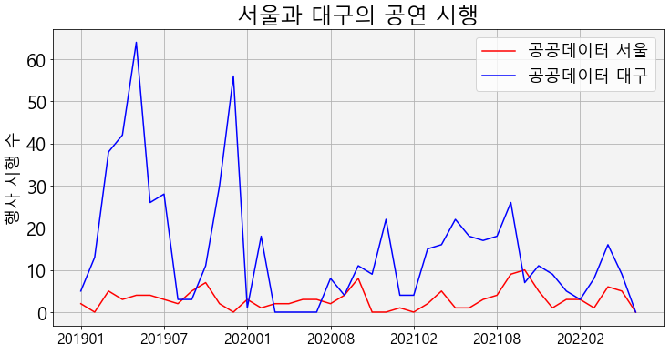

```python
fig = plt.figure(figsize=(12,6))
ax = fig.add_subplot(1, 1, 1)

ax.plot(event_count['공공데이터_서울'], 'r')
ax.plot(event_count['공공데이터_대구'], 'b')
plt.xticks(event_count.index[::6])
plt.ylabel('행사 시행 수')
plt.title('서울과 대구의 공연 시행')
ax.legend(['공공데이터 서울', '공공데이터 대구'])
ax.grid()
ax.set_facecolor('#f3f3f3')
```

```python
daegu_show[(daegu_show['시행월'] == '202109')]
```

|  | 행사명 | 장소 | 소재지도로명주소 | 시행월 |
| --- | --- | --- | --- | --- |
| 506 | 봉포유렉처스테이지II-프렐류드X최석민무용단 | 봉산문화회관 가온홀 | 대구광역시 중구 봉산문화길 77 | 202109 |
| 507 | 청출어람 프로젝트 Ⅱ | 대구문화예술회관 비슬홀 | 대구광역시 달서구 공원순환로 201 | 202109 |
| 508 | 황혜진 해금 독주회 | 대구문화예술회관 비슬홀 | 대구광역시 달서구 공원순환로 201 | 202109 |
| 509 | 제23회 대구 국제무용제 | 대구문화예술회관 팔공홀 | 대구광역시 달서구 공원순환로 201 | 202109 |
| 510 | 제23회 대구 국제무용제 | 대구문화예술회관 비슬홀 | 대구광역시 달서구 공원순환로 201 | 202109 |
| 511 | 제30회 대구 사회복지 대회 | 대구문화예술회관 팔공홀 | 대구광역시 달서구 공원순환로 201 | 202109 |
| 512 | 피아니스트 양성원의 냉정과 열정 사이 | 봉산문화회관 가온홀 | 대구광역시 중구 봉산문화길 77 | 202109 |
| 513 | 경북도립 교향악단 | 대구문화예술회관 팔공홀 | 대구광역시 달서구 공원순환로 201 | 202109 |
| 514 | 2021 대구 예술제 협회 공연 | 대구문화예술회관 비슬홀 | 대구광역시 달서구 공원순환로 201 | 202109 |
| 515 | 우수공연 <리멤버 콘서트> | 서구문화회관 공연장 | 대구광역시 서구 당산로 403 | 202109 |
| 516 | 2021 대구예술제 어워즈 | 대구문화예술회관 팔공홀 | 대구광역시 달서구 공원순환로 201 | 202109 |
| 517 | 2021 대구 예술제 협회 공연 | 대구문화예술회관 비슬홀 | 대구광역시 달서구 공원순환로 201 | 202109 |
| 518 | 2021년치매 극복의 날 기념행사 | 대구문화예술회관 비슬홀 | 대구광역시 달서구 공원순환로 201 | 202109 |
| 519 | 달성음악회 | 관내 | 대구광역시 달성군 논공읍 달성군청로 33 | 202109 |
| 520 | 세대교감 콘서트 “2021 얼쑤 좋다, b-boying 한마당” | 대구문화예술회관 비슬홀 | 대구광역시 달서구 공원순환로 201 | 202109 |
| 521 | 대구문화예술회관 기획공연 마스터즈시리즈 | 대구문화예술회관 팔공홀 | 대구광역시 달서구 공원순환로 201 | 202109 |
| 522 | DCMC Light and motion in daegu 2021 | 대구문화예술회관 비슬홀 | 대구광역시 달서구 공원순환로 201 | 202109 |
| 523 | 루멘투라싱어즈 영상촬영 | 대구문화예술회관 팔공홀 | 대구광역시 달서구 공원순환로 201 | 202109 |
| 524 | 김성하 재즈 콘서트 | 대구문화예술회관 비슬홀 | 대구광역시 달서구 공원순환로 201 | 202109 |
| 525 | 달빛의 노래(하프문 콰이어 정기공연) | 봉산문화회관 가온홀 | 대구광역시 중구 봉산문화길 77 | 202109 |
| 526 | 마토콘서트Ⅷ) 국악콘서트 <서풍> | 이현공원(야외공연) | 대구광역시 서구 당산로 403 | 202109 |
| 527 | 유네스코 음악창의도시 대구 퓨전국악축제 | 대구문화예술회관 팔공홀 | 대구광역시 달서구 공원순환로 201 | 202109 |
| 528 | 화요국악무대 | 대구문화예술회관 비슬홀 | 대구광역시 달서구 공원순환로 201 | 202109 |
| 529 | 달성 100대 피아노 | 화원동산 사문진나루터 | 대구광역시 달성군 화원읍 사문진로1길 40-12 | 202109 |
| 530 | 스핀오프 | 대구문화예술회관 비슬홀 | 대구광역시 달서구 공원순환로 201 | 202109 |
| 531 | 봉포유렉처스테이지III-댄서스테이지 | 봉산문화회관 가온홀 | 대구광역시 중구 봉산문화길 77 | 202109 |

### 인구 자료 활용 비교

```python
seoul_pop2020 = pd.read_csv('seoul_population_2020.csv')
seoul_pop2020
```

|  | 기간 | 자치구 | 동 | 인구 | 면적 | 인구밀도 |
| --- | --- | --- | --- | --- | --- | --- |
| 0 | 2020 | 합계 | 합계 | 9,911,088 | 605.23 | 16,376 |
| 1 | 2020 | 종로구 | 소계 | 158,996 | 23.91 | 6,649 |
| 2 | 2020 | 종로구 | 사직동 | 9,806 | 1.23 | 7,972 |
| 3 | 2020 | 종로구 | 삼청동 | 2,909 | 1.49 | 1,952 |
| 4 | 2020 | 종로구 | 부암동 | 10,333 | 2.27 | 4,552 |
| ... | ... | ... | ... | ... | ... | ... |
| 446 | 2020 | 강동구 | 둔촌1동 | 262 | 0.92 | 285 |
| 447 | 2020 | 강동구 | 둔촌2동 | 26,413 | 0.98 | 26,952 |
| 448 | 2020 | 강동구 | 암사1동 | 35,728 | 1.02 | 35,027 |
| 449 | 2020 | 강동구 | 천호2동 | 35,251 | 1.57 | 22,453 |
| 450 | 2020 | 강동구 | 길동 | 46,868 | 2.17 | 21,598 |

451 rows × 6 columns

```python
daegu_pop2020 = pd.read_excel('daegu_population_2020.xlsx', skiprows= 5, index_col=0)
daegu_pop2020
```

|  | 계 | 남 | 여 | Unnamed: 4 | 계.1 | 남.1 | 여.1 | 계.2 | 남.2 | 여.2 |
| --- | --- | --- | --- | --- | --- | --- | --- | --- | --- | --- |
| 총계 | 2446144 | 1208020 | 1238124 | 1056627 | 2418346 | 1193109 | 1225237 | 27798 | 14911 | 12887 |
| 중구 | 77262 | 37132 | 40130 | 39111 | 76547 | 36799 | 39748 | 715 | 333 | 382 |
| 동구 | 343685 | 169034 | 174651 | 155865 | 341920 | 168443 | 173477 | 1765 | 591 | 1174 |
| 서구 | 172879 | 86770 | 86109 | 83437 | 170700 | 85572 | 85128 | 2179 | 1198 | 981 |
| 남구 | 148247 | 71170 | 77077 | 76582 | 146632 | 70471 | 76161 | 1615 | 699 | 916 |
| 북구 | 444923 | 221416 | 223507 | 187494 | 440263 | 219197 | 221066 | 4660 | 2219 | 2441 |
| 수성구 | 425987 | 205983 | 220004 | 170870 | 424314 | 205293 | 219021 | 1673 | 690 | 983 |
| 달서구 | 568481 | 281390 | 287091 | 235303 | 558631 | 275626 | 283005 | 9850 | 5764 | 4086 |
| 달성군 | 264680 | 135125 | 129555 | 107965 | 259339 | 131708 | 127631 | 5341 | 3417 | 1924 |

```python
seoul_pop2020 = seoul_pop2020[['자치구', '인구']].set_index('자치구')
daegu_pop2020 = daegu_pop2020[['계', '남', '여']].rename(columns = {'계' : '인구'})
```

```python
seoul_pop2020
```

| 자치구 | 인구 |
| --- | --- |
| 합계 | 9,911,088 |
| 종로구 | 158,996 |
| 종로구 | 9,806 |
| 종로구 | 2,909 |
| 종로구 | 10,333 |
| ... | ... |
| 강동구 | 262 |
| 강동구 | 26,413 |
| 강동구 | 35,728 |
| 강동구 | 35,251 |
| 강동구 | 46,868 |

451 rows × 1 columns

```python
daegu_pop2020
```

|  | 인구 | 남 | 여 |
| --- | --- | --- | --- |
| 총계 | 2446144 | 1208020 | 1238124 |
| 중구 | 77262 | 37132 | 40130 |
| 동구 | 343685 | 169034 | 174651 |
| 서구 | 172879 | 86770 | 86109 |
| 남구 | 148247 | 71170 | 77077 |
| 북구 | 444923 | 221416 | 223507 |
| 수성구 | 425987 | 205983 | 220004 |
| 달서구 | 568481 | 281390 | 287091 |
| 달성군 | 264680 | 135125 | 129555 |

```python
seoul_pop, daegu_pop = seoul_pop2020.iloc[0,0], daegu_pop2020.iloc[0,0]
```

```python
seoul_pop, daegu_pop
```

```
('9,911,088', 2446144)
```

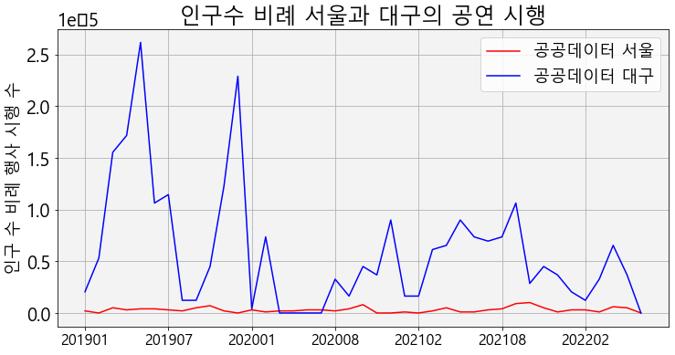

```python
plt.rc('font', size=20)        # 기본 폰트 크기
plt.rc('axes', labelsize=18)   # x,y축 label 폰트 크기
plt.rc('xtick', labelsize=16)  # x축 눈금 폰트 크기
plt.rc('ytick', labelsize=20)  # y축 눈금 폰트 크기
plt.rc('legend', fontsize=18)  # 범례 폰트 크기
plt.rc('figure', titlesize=30) # figure title 폰트 크기


fig = plt.figure(figsize=(12,6))
ax = fig.add_subplot(1, 1, 1)

ax.plot(event_count['공공데이터_서울']/int(seoul_pop.replace(',','')), 'r')
ax.plot(event_count['공공데이터_대구']/daegu_pop, 'b')
plt.xticks(event_count.index[::6])
plt.ylabel('인구 수 비례 행사 시행 수')
plt.title('인구수 비례 서울과 대구의 공연 시행')
ax.legend(['공공데이터 서울', '공공데이터 대구'])
ax.grid()
ax.set_facecolor('#f3f3f3')
```

### 야놀자 자료 분석

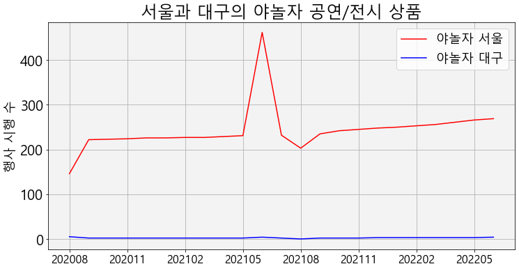

```python
fig = plt.figure(figsize=(12,6))
ax = fig.add_subplot(1, 1, 1)

ax.plot(event_count['야놀자_서울'][18:], 'r')
ax.plot(event_count['야놀자_대구'][18:], 'b')
plt.xticks(event_count.index[18::3])
plt.ylabel('행사 시행 수')
plt.title('서울과 대구의 야놀자 공연/전시 상품')
ax.legend(['야놀자 서울', '야놀자 대구'])
ax.grid()
ax.set_facecolor('#f3f3f3')
```

야놀자 어플 내의 공연/행사 상품 수 비교에서

대구 자료가 압도적으로 적어 분석이 어렵다.

실제로 야놀자 어플에서 대구의 공연/ 전시를 검색해 보면 단 한개의 상품만 존재한다.

```python
seoul_yanolza[seoul_yanolza['시행월'] == '202106']
```

|  | 지역 | 행사명 | 시행월 |
| --- | --- | --- | --- |
| 2181 | 서울 강남구 | [서울 강남] 피규어뮤지엄 W(키덜트) | 202106 |
| 2182 | 서울 강남구 | [서울 강남] 마녀의 초대장★전시 | 202106 |
| 2183 | 서울 강남구 | [서울 강남] 나의어린왕자에게展 | 202106 |
| 2184 | 서울 강남구 | [서울 강남] 코엑스 2018 서울 디저트쇼 | 202106 |
| 2185 | 서울 강남구 | [서울 강남] 산타와 빈양말 : 어린이 뮤지컬 | 202106 |
| ... | ... | ... | ... |
| 2638 | 서울특별시 마포구 | [서울 마포] 홍대 비밀의 숲 | 202106 |
| 2639 | 서울특별시 성동구 | [서울 성동] 빨강머리앤 : 전시회 | 202106 |
| 2640 | 서울특별시 성동구 | [서울 성동] 내 이름은 빨강머리 앤 야놀자 특가 ★ | 202106 |
| 2641 | 서울특별시 성동구 | [서울 성동] 빨강머리앤 : 전시회 | 202106 |
| 2642 | 서울특별시 성동구 | [서울 성동] 빨강머리앤 : 전시회 3월 | 202106 |

462 rows × 3 columns

```python
seoul_yanolza_2106 = seoul_yanolza[seoul_yanolza['시행월'] == '202106']
```

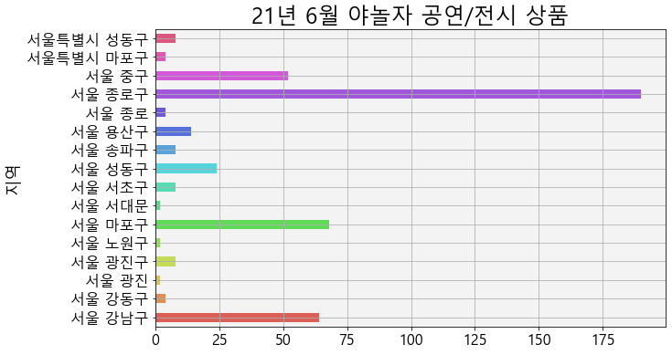

```python
import seaborn as sns
plt.rc('font', size=20)        # 기본 폰트 크기
plt.rc('axes', labelsize=18)   # x,y축 label 폰트 크기
plt.rc('xtick', labelsize=16)  # x축 눈금 폰트 크기
plt.rc('ytick', labelsize=16)  # y축 눈금 폰트 크기
plt.rc('legend', fontsize=18)  # 범례 폰트 크기
plt.rc('figure', titlesize=30) # figure title 폰트 크기

fig = plt.figure(figsize=(10,6))
ax = fig.add_subplot(1, 1, 1)

colors = sns.color_palette('hls',seoul_yanolza_2106['지역'].nunique())

seoul_yanolza_2106.groupby('지역').count()['시행월'].plot.barh(color = colors)

plt.ylabel('지역')
plt.title('21년 6월 야놀자 공연/전시 상품')
ax.grid()
ax.set_facecolor('#f3f3f3')
```

```python
seoul_yanolza_2106[seoul_yanolza_2106['지역'] == '서울 종로구']['행사명'].value_counts()
```

```
[서울 종로] 로맨틱코미디 연극 한뼘사이                 6
[서울 종로] 웰메이드 감성연극 최고의사랑★공연             4
[서울 종로] 코믹추리스릴러극 행오버                   4
[서울 종로] 극적인하룻밤★공연                      4
[서울 종로] The Flower hello심쿵전 이색전시회      2
                                      ..
[서울 종로] 극적인하룻밤 2월★공연                   2
[서울 종로] 대학로 라이어 1탄 2월★연극               2
[서울 종로] 마녀정원  展                        2
[서울 대학로] 연극 하트시그널 2월★공연                2
[빼빼로위크★] The Flower hello,심쿵전 1+1특가    2
Name: 행사명, Length: 90, dtype: int64
```

### 공공데이터, 야놀자 공연 자료 통합 비교

```python
total = event_count.loc['202008':].copy()
total['서울'] = total['공공데이터_서울']+total['야놀자_서울']
total['대구'] = total['공공데이터_대구']+total['야놀자_대구']
```

```python
total
```

| 시행월 | 공공데이터_서울 | 공공데이터_대구 | 야놀자_서울 | 야놀자_대구 | 서울 | 대구 |
| --- | --- | --- | --- | --- | --- | --- |
| 202008 | 2.0 | 8.0 | 146.0 | 5.0 | 148.0 | 13.0 |
| 202009 | 4.0 | 4.0 | 222.0 | 2.0 | 226.0 | 6.0 |
| 202010 | 8.0 | 11.0 | 223.0 | 2.0 | 231.0 | 13.0 |
| 202011 | 0.0 | 9.0 | 224.0 | 2.0 | 224.0 | 11.0 |
| 202012 | 0.0 | 22.0 | 226.0 | 2.0 | 226.0 | 24.0 |
| 202101 | 1.0 | 4.0 | 226.0 | 2.0 | 227.0 | 6.0 |
| 202102 | 0.0 | 4.0 | 227.0 | 2.0 | 227.0 | 6.0 |
| 202103 | 2.0 | 15.0 | 227.0 | 2.0 | 229.0 | 17.0 |
| 202104 | 5.0 | 16.0 | 229.0 | 2.0 | 234.0 | 18.0 |
| 202105 | 1.0 | 22.0 | 231.0 | 2.0 | 232.0 | 24.0 |
| 202106 | 1.0 | 18.0 | 462.0 | 4.0 | 463.0 | 22.0 |
| 202107 | 3.0 | 17.0 | 232.0 | 2.0 | 235.0 | 19.0 |
| 202108 | 4.0 | 18.0 | 203.0 | 0.0 | 207.0 | 18.0 |
| 202109 | 9.0 | 26.0 | 235.0 | 2.0 | 244.0 | 28.0 |
| 202110 | 10.0 | 7.0 | 242.0 | 2.0 | 252.0 | 9.0 |
| 202111 | 5.0 | 11.0 | 245.0 | 2.0 | 250.0 | 13.0 |
| 202112 | 1.0 | 9.0 | 248.0 | 3.0 | 249.0 | 12.0 |
| 202201 | 3.0 | 5.0 | 250.0 | 3.0 | 253.0 | 8.0 |
| 202202 | 3.0 | 3.0 | 253.0 | 3.0 | 256.0 | 6.0 |
| 202203 | 1.0 | 8.0 | 256.0 | 3.0 | 257.0 | 11.0 |
| 202204 | 6.0 | 16.0 | 261.0 | 3.0 | 267.0 | 19.0 |
| 202205 | 5.0 | 9.0 | 266.0 | 3.0 | 271.0 | 12.0 |
| 202206 | 0.0 | 0.0 | 269.0 | 4.0 | 269.0 | 4.0 |

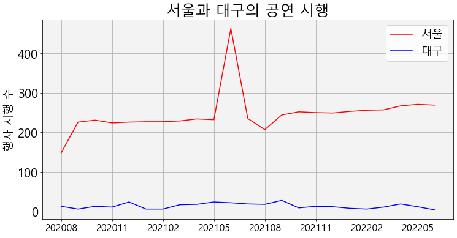

```python
plt.rc('font', size=20)        # 기본 폰트 크기
plt.rc('axes', labelsize=18)   # x,y축 label 폰트 크기
plt.rc('xtick', labelsize=16)  # x축 눈금 폰트 크기
plt.rc('ytick', labelsize=20)  # y축 눈금 폰트 크기
plt.rc('legend', fontsize=18)  # 범례 폰트 크기
plt.rc('figure', titlesize=30) # figure title 폰트 크기


fig = plt.figure(figsize=(12,6))
ax = fig.add_subplot(1, 1, 1)

ax.plot(total['서울'], 'r')
ax.plot(total['대구'], 'b')
plt.xticks(total.index[::3])
plt.ylabel('행사 시행 수')
plt.title('서울과 대구의 공연 시행')
ax.legend(['서울', '대구'])
ax.grid()
ax.set_facecolor('#f3f3f3')
```

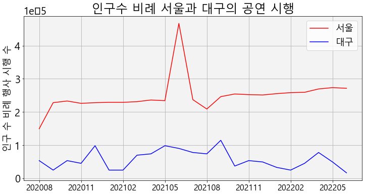

```python
plt.rc('font', size=20)        # 기본 폰트 크기
plt.rc('axes', labelsize=18)   # x,y축 label 폰트 크기
plt.rc('xtick', labelsize=16)  # x축 눈금 폰트 크기
plt.rc('ytick', labelsize=20)  # y축 눈금 폰트 크기
plt.rc('legend', fontsize=18)  # 범례 폰트 크기
plt.rc('figure', titlesize=30) # figure title 폰트 크기


fig = plt.figure(figsize=(12,6))
ax = fig.add_subplot(1, 1, 1)

ax.plot(total['서울']/int(seoul_pop.replace(',','')), 'r')
ax.plot(total['대구']/daegu_pop, 'b')
plt.xticks(total.index[::3])
plt.ylabel('인구 수 비례 행사 시행 수')
plt.title('인구수 비례 서울과 대구의 공연 시행')
ax.legend(['서울', '대구'])
ax.grid()
ax.set_facecolor('#f3f3f3')
```

### 대구내 구 별 행사 수 비교

```python
daegu_show['소재지도로명주소']
```

```
0         대구광역시 중구 봉산문화길 77
1         대구광역시 중구 봉산문화길 77
2         대구광역시 중구 봉산문화길 77
3         대구광역시 중구 봉산문화길 77
4         대구광역시 중구 봉산문화길 77
               ...
595       대구광역시 중구 봉산문화길 77
596      대구광역시 남구 앞산순환로 478
597    대구광역시 북구 구암로 47(관음동)
598       대구광역시 중구 봉산문화길 77
599        대구광역시 서구 당산로 403
Name: 소재지도로명주소, Length: 600, dtype: object
```

```python
daegu_show['소재지도로명주소'] = [' '.join(x.split()[:2]) for x in daegu_show['소재지도로명주소'] ]
daegu_show
```

|  | 행사명 | 장소 | 소재지도로명주소 | 시행월 |
| --- | --- | --- | --- | --- |
| 0 | 2019 웨스턴심포니 오케스트라와 함께하는 신년음악회 with 장사익 | 봉산문화회관 가온홀 | 대구광역시 중구 | 201901 |
| 1 | 가족뮤지컬 렛잇고 | 봉산문화회관 가온홀 | 대구광역시 중구 | 201901 |
| 2 | 가족뮤지컬 렛잇고 | 봉산문화회관 가온홀 | 대구광역시 중구 | 201901 |
| 3 | 가족뮤지컬 렛잇고 | 봉산문화회관 가온홀 | 대구광역시 중구 | 201901 |
| 4 | 가족뮤지컬 렛잇고 | 봉산문화회관 가온홀 | 대구광역시 중구 | 201901 |
| ... | ... | ... | ... | ... |
| 595 | 음악무용극 불켜는 아이 | 봉산문화회관 가온홀 | 대구광역시 중구 | 202205 |
| 596 | 향기의 미술관 | 대구음악창작소 창공홀 | 대구광역시 남구 | 202205 |
| 597 | 마임연극<내 마음에 꽃이 피었습니다> | 어울아트센터 오봉홀 | 대구광역시 북구 | 202205 |
| 598 | 소소스테이지I - 퍼플엘리 of 비아트리오 | 봉산문화회관 스페이스라온 | 대구광역시 중구 | 202205 |
| 599 | 마토콘서트 <퓨전 마당극 춘심홍로줄> | 이현공원 야외공연장 | 대구광역시 서구 | 202205 |

600 rows × 4 columns

```python
daegu_gu_month = daegu_show.groupby(['시행월', '소재지도로명주소']).count()['행사명'].unstack().fillna(0)
daegu_gu = daegu_gu_month.mean()
daegu_gu_month.describe()
```

| 소재지도로명주소 | 대구광역시 남구 | 대구광역시 달서구 | 대구광역시 달성군 | 대구광역시 북구 | 대구광역시 서구 | 대구광역시 수성구 | 대구광역시 중구 |
| --- | --- | --- | --- | --- | --- | --- | --- |
| count | 36.000000 | 36.000000 | 36.000000 | 36.000000 | 36.000000 | 36.000000 | 36.000000 |
| mean | 1.361111 | 3.111111 | 0.194444 | 0.055556 | 1.222222 | 0.027778 | 10.694444 |
| std | 1.290687 | 5.208662 | 0.467177 | 0.333333 | 1.640751 | 0.166667 | 15.294853 |
| min | 0.000000 | 0.000000 | 0.000000 | 0.000000 | 0.000000 | 0.000000 | 0.000000 |
| 25% | 0.000000 | 0.000000 | 0.000000 | 0.000000 | 0.000000 | 0.000000 | 2.000000 |
| 50% | 1.000000 | 0.000000 | 0.000000 | 0.000000 | 0.000000 | 0.000000 | 4.500000 |
| 75% | 2.250000 | 4.250000 | 0.000000 | 0.000000 | 2.000000 | 0.000000 | 10.000000 |
| max | 4.000000 | 18.000000 | 2.000000 | 2.000000 | 7.000000 | 1.000000 | 62.000000 |

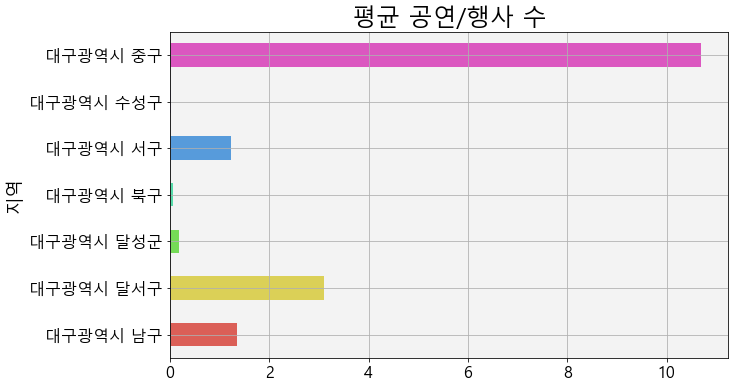

```python
import seaborn as sns
plt.rc('font', size=20)        # 기본 폰트 크기
plt.rc('axes', labelsize=18)   # x,y축 label 폰트 크기
plt.rc('xtick', labelsize=16)  # x축 눈금 폰트 크기
plt.rc('ytick', labelsize=16)  # y축 눈금 폰트 크기
plt.rc('legend', fontsize=18)  # 범례 폰트 크기
plt.rc('figure', titlesize=30) # figure title 폰트 크기

fig = plt.figure(figsize=(10,6))
ax = fig.add_subplot(1, 1, 1)

colors = sns.color_palette('hls',len(daegu_gu.index))

daegu_gu.plot.barh(color = colors)

plt.ylabel('지역')
plt.title('평균 공연/행사 수')
ax.grid()
ax.set_facecolor('#f3f3f3')
```

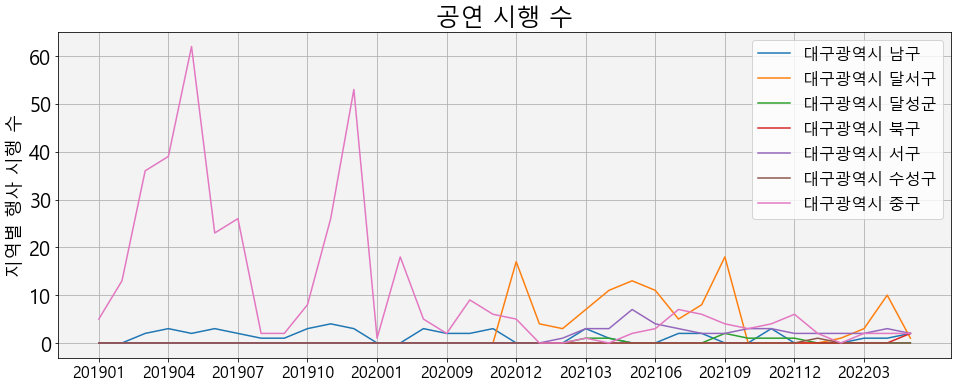

```python
plt.rc('font', size=20)        # 기본 폰트 크기
plt.rc('axes', labelsize=18)   # x,y축 label 폰트 크기
plt.rc('xtick', labelsize=16)  # x축 눈금 폰트 크기
plt.rc('ytick', labelsize=20)  # y축 눈금 폰트 크기
plt.rc('legend', fontsize=16)  # 범례 폰트 크기
plt.rc('figure', titlesize=30) # figure title 폰트 크기


fig = plt.figure(figsize=(16,6))
ax = fig.add_subplot(1, 1, 1)

ax.plot(daegu_gu_month)
plt.xticks(daegu_gu_month.index[::3])
plt.ylabel('지역별 행사 시행 수')
plt.title('공연 시행 수')
ax.legend(daegu_gu_month.columns)
ax.grid()
ax.set_facecolor('#f3f3f3')
```

### 서울내 구 별 행사 수 비교

```python
seoul_show['소재지도로명주소']
```

```
4        서울특별시 서대문구 연희로 248
5        서울특별시 양천구 목동서로 367
6         서울특별시 마포구 월드컵로240
7         서울특별시 마포구 월드컵로240
8        서울특별시 양천구 목동서로 367
               ...
124    서울특별시 서초구 남부순환로 2406
125     서울특별시 강남구 압구정로22길21
126       서울특별시 강북구 삼각산로 85
127     서울특별시 영등포구 국회대로 596
128       서울특별시 강북구 삼각산로 85
Name: 소재지도로명주소, Length: 125, dtype: object
```

```python
seoul_show['소재지도로명주소'] = [' '.join(x.split()[:2]) for x in seoul_show['소재지도로명주소'] ]
seoul_show
```

|  | 행사명 | 장소 | 소재지도로명주소 | 시행월 |
| --- | --- | --- | --- | --- |
| 4 | 안산해맞이 | 안산봉수대 | 서울특별시 서대문구 | 201901 |
| 5 | 2019 신년음악회 | 양천문화회관 대극장 | 서울특별시 양천구 | 201901 |
| 6 | 2019 K리그1 서울vs포항 | 주경기장 | 서울특별시 마포구 | 201903 |
| 7 | 2019 K리그1 서울vs제주 | 주경기장 | 서울특별시 마포구 | 201903 |
| 8 | 3.1운동 100주년기념 음악회 | 양천문화회관 대극장 | 서울특별시 양천구 | 201903 |
| ... | ... | ... | ... | ... |
| 124 | 2022년 강남심포니오케스트라 정기연주회 | 예술의전당 콘서트홀 | 서울특별시 서초구 | 202205 |
| 125 | 2022년 클래식품격콘서트 | 광림아트센터 장천아트홀 | 서울특별시 강남구 | 202205 |
| 126 | 예술의전당 SAC on Screen 뮤지컬 명성황후 | 서울특별시 강북구 강북문화예술회관 대공연장 | 서울특별시 강북구 | 202205 |
| 127 | 에스메의 여름 | 영등포아트홀 공연장 | 서울특별시 영등포구 | 202205 |
| 128 | 예술의전당 SAC on Screen 발레 지젤 | 서울특별시 강북구 강북문화예술회관 대공연장 | 서울특별시 강북구 | 202205 |

125 rows × 4 columns

```python
seoul_gu_month = seoul_show.groupby(['시행월', '소재지도로명주소']).count()['행사명'].unstack().fillna(0)
seoul_gu = seoul_gu_month.mean()
seoul_gu_month
```

| 소재지도로명주소 시행월 | - | 서울특별시 강남구 | 서울특별시 강동구 | 서울특별시 강북구 | 서울특별시 강서구 | 서울특별시 광진구 | 서울특별시 금천구 | 서울특별시 동작구 | 서울특별시 마포구 | 서울특별시 서대문구 | 서울특별시 서초구 | 서울특별시 송파구 | 서울특별시 양천구 | 서울특별시 영등포구 | 서울특별시 은평구 | 서울특별시 종로구 | 서울특별시 중랑구 |
| --- | --- | --- | --- | --- | --- | --- | --- | --- | --- | --- | --- | --- | --- | --- | --- | --- | --- |
| 201901 | 0.0 | 0.0 | 0.0 | 0.0 | 0.0 | 0.0 | 0.0 | 0.0 | 0.0 | 1.0 | 0.0 | 0.0 | 1.0 | 0.0 | 0.0 | 0.0 | 0.0 |
| 201903 | 0.0 | 0.0 | 0.0 | 0.0 | 0.0 | 0.0 | 0.0 | 0.0 | 4.0 | 0.0 | 0.0 | 0.0 | 1.0 | 0.0 | 0.0 | 0.0 | 0.0 |
| 201904 | 0.0 | 0.0 | 0.0 | 0.0 | 0.0 | 0.0 | 0.0 | 0.0 | 2.0 | 1.0 | 0.0 | 0.0 | 0.0 | 0.0 | 0.0 | 0.0 | 0.0 |
| 201905 | 0.0 | 0.0 | 0.0 | 0.0 | 0.0 | 0.0 | 0.0 | 0.0 | 3.0 | 0.0 | 0.0 | 0.0 | 1.0 | 0.0 | 0.0 | 0.0 | 0.0 |
| 201906 | 0.0 | 0.0 | 0.0 | 0.0 | 0.0 | 0.0 | 0.0 | 0.0 | 3.0 | 1.0 | 0.0 | 0.0 | 0.0 | 0.0 | 0.0 | 0.0 | 0.0 |
| 201907 | 0.0 | 0.0 | 0.0 | 0.0 | 0.0 | 0.0 | 0.0 | 0.0 | 2.0 | 0.0 | 0.0 | 0.0 | 1.0 | 0.0 | 0.0 | 0.0 | 0.0 |
| 201908 | 0.0 | 0.0 | 0.0 | 0.0 | 0.0 | 0.0 | 0.0 | 0.0 | 2.0 | 0.0 | 0.0 | 0.0 | 0.0 | 0.0 | 0.0 | 0.0 | 0.0 |
| 201909 | 0.0 | 0.0 | 0.0 | 0.0 | 0.0 | 0.0 | 0.0 | 0.0 | 4.0 | 0.0 | 0.0 | 0.0 | 1.0 | 0.0 | 0.0 | 0.0 | 0.0 |
| 201910 | 0.0 | 0.0 | 0.0 | 0.0 | 0.0 | 0.0 | 0.0 | 0.0 | 5.0 | 0.0 | 0.0 | 0.0 | 2.0 | 0.0 | 0.0 | 0.0 | 0.0 |
| 201911 | 0.0 | 0.0 | 0.0 | 0.0 | 0.0 | 0.0 | 0.0 | 0.0 | 2.0 | 0.0 | 0.0 | 0.0 | 0.0 | 0.0 | 0.0 | 0.0 | 0.0 |
| 202001 | 0.0 | 0.0 | 0.0 | 0.0 | 0.0 | 0.0 | 0.0 | 0.0 | 1.0 | 0.0 | 1.0 | 1.0 | 0.0 | 0.0 | 0.0 | 0.0 | 0.0 |
| 202002 | 0.0 | 0.0 | 0.0 | 0.0 | 0.0 | 0.0 | 0.0 | 0.0 | 1.0 | 0.0 | 0.0 | 0.0 | 0.0 | 0.0 | 0.0 | 0.0 | 0.0 |
| 202004 | 0.0 | 0.0 | 0.0 | 0.0 | 0.0 | 0.0 | 0.0 | 0.0 | 0.0 | 0.0 | 0.0 | 2.0 | 0.0 | 0.0 | 0.0 | 0.0 | 0.0 |
| 202005 | 0.0 | 0.0 | 0.0 | 0.0 | 0.0 | 0.0 | 0.0 | 0.0 | 2.0 | 0.0 | 0.0 | 0.0 | 0.0 | 0.0 | 0.0 | 0.0 | 0.0 |
| 202006 | 0.0 | 0.0 | 0.0 | 0.0 | 0.0 | 0.0 | 0.0 | 0.0 | 3.0 | 0.0 | 0.0 | 0.0 | 0.0 | 0.0 | 0.0 | 0.0 | 0.0 |
| 202007 | 0.0 | 0.0 | 0.0 | 0.0 | 0.0 | 1.0 | 0.0 | 0.0 | 2.0 | 0.0 | 0.0 | 0.0 | 0.0 | 0.0 | 0.0 | 0.0 | 0.0 |
| 202008 | 0.0 | 0.0 | 0.0 | 0.0 | 0.0 | 0.0 | 0.0 | 0.0 | 2.0 | 0.0 | 0.0 | 0.0 | 0.0 | 0.0 | 0.0 | 0.0 | 0.0 |
| 202009 | 0.0 | 0.0 | 1.0 | 0.0 | 0.0 | 0.0 | 0.0 | 0.0 | 3.0 | 0.0 | 0.0 | 0.0 | 0.0 | 0.0 | 0.0 | 0.0 | 0.0 |
| 202010 | 0.0 | 0.0 | 1.0 | 0.0 | 0.0 | 2.0 | 0.0 | 0.0 | 3.0 | 0.0 | 0.0 | 0.0 | 0.0 | 0.0 | 0.0 | 2.0 | 0.0 |
| 202101 | 0.0 | 0.0 | 0.0 | 0.0 | 0.0 | 0.0 | 0.0 | 0.0 | 0.0 | 0.0 | 0.0 | 0.0 | 0.0 | 0.0 | 1.0 | 0.0 | 0.0 |
| 202103 | 0.0 | 0.0 | 0.0 | 0.0 | 0.0 | 0.0 | 0.0 | 0.0 | 2.0 | 0.0 | 0.0 | 0.0 | 0.0 | 0.0 | 0.0 | 0.0 | 0.0 |
| 202104 | 0.0 | 0.0 | 0.0 | 0.0 | 0.0 | 0.0 | 0.0 | 0.0 | 5.0 | 0.0 | 0.0 | 0.0 | 0.0 | 0.0 | 0.0 | 0.0 | 0.0 |
| 202105 | 0.0 | 0.0 | 0.0 | 0.0 | 0.0 | 0.0 | 0.0 | 0.0 | 1.0 | 0.0 | 0.0 | 0.0 | 0.0 | 0.0 | 0.0 | 0.0 | 0.0 |
| 202106 | 0.0 | 0.0 | 0.0 | 0.0 | 0.0 | 0.0 | 0.0 | 0.0 | 1.0 | 0.0 | 0.0 | 0.0 | 0.0 | 0.0 | 0.0 | 0.0 | 0.0 |
| 202107 | 0.0 | 0.0 | 0.0 | 0.0 | 0.0 | 0.0 | 0.0 | 0.0 | 3.0 | 0.0 | 0.0 | 0.0 | 0.0 | 0.0 | 0.0 | 0.0 | 0.0 |
| 202108 | 0.0 | 0.0 | 0.0 | 0.0 | 0.0 | 0.0 | 0.0 | 0.0 | 4.0 | 0.0 | 0.0 | 0.0 | 0.0 | 0.0 | 0.0 | 0.0 | 0.0 |
| 202109 | 0.0 | 0.0 | 0.0 | 0.0 | 0.0 | 0.0 | 5.0 | 0.0 | 4.0 | 0.0 | 0.0 | 0.0 | 0.0 | 0.0 | 0.0 | 0.0 | 0.0 |
| 202110 | 4.0 | 0.0 | 0.0 | 0.0 | 0.0 | 0.0 | 4.0 | 1.0 | 1.0 | 0.0 | 0.0 | 0.0 | 0.0 | 0.0 | 0.0 | 0.0 | 0.0 |
| 202111 | 0.0 | 0.0 | 0.0 | 0.0 | 0.0 | 0.0 | 5.0 | 0.0 | 0.0 | 0.0 | 0.0 | 0.0 | 0.0 | 0.0 | 0.0 | 0.0 | 0.0 |
| 202112 | 0.0 | 0.0 | 0.0 | 0.0 | 0.0 | 0.0 | 1.0 | 0.0 | 0.0 | 0.0 | 0.0 | 0.0 | 0.0 | 0.0 | 0.0 | 0.0 | 0.0 |
| 202201 | 1.0 | 0.0 | 0.0 | 0.0 | 1.0 | 0.0 | 0.0 | 0.0 | 0.0 | 0.0 | 0.0 | 0.0 | 0.0 | 0.0 | 0.0 | 0.0 | 1.0 |
| 202202 | 0.0 | 1.0 | 0.0 | 0.0 | 0.0 | 0.0 | 0.0 | 0.0 | 0.0 | 0.0 | 1.0 | 0.0 | 0.0 | 0.0 | 0.0 | 0.0 | 1.0 |
| 202203 | 0.0 | 1.0 | 0.0 | 0.0 | 0.0 | 0.0 | 0.0 | 0.0 | 0.0 | 0.0 | 0.0 | 0.0 | 0.0 | 0.0 | 0.0 | 0.0 | 0.0 |
| 202204 | 2.0 | 1.0 | 0.0 | 1.0 | 0.0 | 0.0 | 0.0 | 0.0 | 0.0 | 0.0 | 1.0 | 0.0 | 0.0 | 1.0 | 0.0 | 0.0 | 0.0 |
| 202205 | 0.0 | 1.0 | 0.0 | 2.0 | 0.0 | 0.0 | 0.0 | 0.0 | 0.0 | 0.0 | 1.0 | 0.0 | 0.0 | 1.0 | 0.0 | 0.0 | 0.0 |

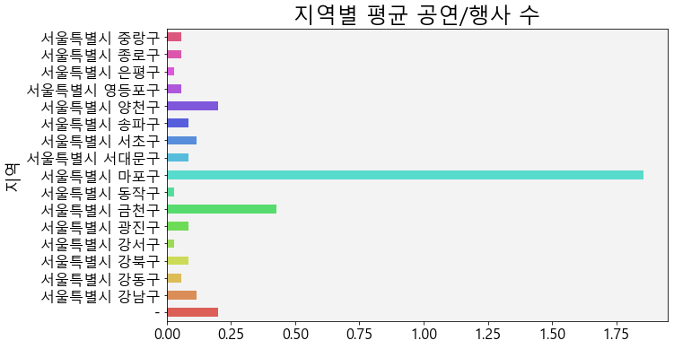

```python
import seaborn as sns
plt.rc('font', size=20)        # 기본 폰트 크기
plt.rc('axes', labelsize=18)   # x,y축 label 폰트 크기
plt.rc('xtick', labelsize=16)  # x축 눈금 폰트 크기
plt.rc('ytick', labelsize=16)  # y축 눈금 폰트 크기
plt.rc('legend', fontsize=18)  # 범례 폰트 크기
plt.rc('figure', titlesize=30) # figure title 폰트 크기

fig = plt.figure(figsize=(10,6))
ax = fig.add_subplot(1, 1, 1)

colors = sns.color_palette('hls',len(seoul_gu.index))

seoul_gu.plot.barh(color = colors)
ax.grid()
ax.set_facecolor('#f3f3f3')

plt.ylabel('지역')
plt.title('지역별 평균 공연/행사 수')
ax.grid()
ax.set_facecolor('#f3f3f3')
```

### 결론

- 공공 데이터 내에서
  - 문화/ 공연이 시행 횟수 자체는 서울이 대구보다 많지만,
  - 인구수 비례 시행 횟수는 유사하거나 대구가 더 많다.
- 공공 데이터와 야놀자 상품 목록 통합 데이터 에서
  - 전체적인 공연 시행 수가 서울이 압도적으로 많았고
  - 인구 수 비례 시행 정도도 서울이 높았다.
  - 공공데이터 내의 자료는 대구가 더욱 많지만, 야놀자 어플 상품의 수가 서울 내에 매우 많아 이런 결과를 보였다.
- 구별 분석에서
  - 대구 내에서는 공연이 중구와 달서구에 집중되어 있고
  - 20년 12월 이전에는 중구, 이후는 달서구에 많은 공연이 있었다.
  - 서울 내에서는 마포구에 집중되어 있다.

#### 부족한 점

- 공공 데이터 자료에서는 지역의 구별로 시행내역이 저장 되어 있어 각 데이터의 기간이 일정하지 않았다.
- 어떤 자료는 2022년의 자료만 있는것도 존재 하였다.